# STAT 184 project

Wind resources and GDP

Ziang Shi

### abstract

Green energy is a key innovation that discovered in the recent years. It will essentially replace the fossil fuel and take a important role in the global energy market. Not only it will reduce the CO2 emission, the green energy can also be created by non- physical matters such as sun light or wind. Wind power is a special energy resource that based on the electricity generation from the wind power plant. It requires strict geographical features to build and electricity generation is hard to examine before implementation. Based on 2018 data resource, United States of America currently has 430 wind power plant that operate.

### Guiding question

1. What is the shape of the distribution of wind power plant looks like?
2. Does the number of wind power plant affect the GDP in the local state?
3. If possible, predict new location of the wind power plant construction？

### data resource

The table comes from the website https://openei.org/datasets/dataset/miller-keith-2018-windplantdata/resource/3bf6f992-69fc-4ff1-a07f-8f9b97f97571 and the data source comes from openei.org. The data has been collected two scholars Miller and Keith (2018, Environ. Res. Lett. 13 104008), collected in 2018.

The gdp by state is generated from the dataset from the bea.gov website. The full data table contain the gdp by quarters in 2018, comparing with the data in 2017. The data has been collected by the governmental official.

### indices checksheet:

—–data access: (52-55) .Rmd Line numbers where at least two different data sources are imported (59,63) .Rmd Line numbers for inspecting data intake  
—–data wrangling: (69-78,87-91) .Rmd Line number(s) for general data wrangling (80-84) .Rmd Line number(s) for a join operation (94-97) .Rmd Line number(s) for use of reduction and/or transformation functions (99-102) .Rmd Line number(s) for use of regular expressions (104-111) .Rmd Line number(s) for use of machine learning (not “wrangling” but scored here) —–data visualization: (115-120,136-143) .Rmd Line number(s) for use of multiple different geoms: (146-154) .Rmd Line number(s) for use of layered graphics:  
(158-160) .Rmd Line number(s) for use of decision tree or dendogram results:  
## library package

```r
library(tidyverse)
library(mosaic)
library(DataComputing)
```

```r
library(usmap)
library(ggplot2)
library(RColorBrewer)
```

## data accesss

```r
windplant <- read.csv(file = "millerkeith2018data1.csv")
stategdp <- read.csv(file = "stategdp2018q4.csv" )
```

data inspecting :

```r
glimpse(windplant)
```

```
Rows: 430
Columns: 9
$ Plant_Code       <int> 59118, 57751, 57752, 59320, 60059, 57802, 56661, 56795, 57095, 59654, 57927, 60104, 58021, 57260, 58424, 56983, 57212, 5800...
$ Longitude        <dbl> -97.46611, -97.58570, -97.66680, -98.80611, -98.57155, -97.69111, -97.59940, -97.50770, -97.54990, -98.91667, -97.78917, -9...
$ Latitude         <dbl> 26.19528, 26.33072, 26.34892, 26.38861, 26.41169, 26.47528, 27.00110, 27.07020, 27.11970, 27.18000, 27.22306, 27.32000, 27....
$ InstCapMWi       <dbl> 165.0, 200.0, 201.6, 200.0, 110.0, 203.0, 283.2, 201.6, 201.0, 78.0, 188.0, 249.7, 92.0, 150.0, 9.0, 180.0, 200.1, 99.8, 14...
$ AreaKM2          <dbl> 125.580, 52.317, 65.786, 101.222, 48.131, 94.725, 55.967, 69.849, 92.224, 208.797, 160.638, 213.375, 29.025, 65.743, 23.832...
$ NetGENe_2016_MWe <dbl> 56.802368, 65.748975, 60.532332, 72.261384, 42.408242, 72.676343, 77.553620, 58.068192, 53.493966, 34.247723, 60.635018, 10...
$ USWTDB_ID        <chr> "Cameron", "Los Vientos I", "Los Vientos II", "Los Vientos IV", "Los Vientos V", "Magic Valley", "Gulf Wind", "Penescal", "...
$ State            <chr> "Texas", "Texas", "Texas", "Texas", "Texas", "Texas", "Texas", "Texas", "Texas", "Texas", "Texas", "Texas", "Texas", "Texas...
$ Yaxis            <fct> South, South, South, South, South, South, South, South, South, South, South, South, South, South, South, South, South, Sout...
```

```r
head(stategdp)
```

|  | State | X2018Q4 |
| --- | --- | --- |
| 1 | Alabama | 224654 |
| 2 | Alaska | 54851 |
| 3 | Arizona | 355311 |
| 4 | Arkansas | 129812 |
| 5 | California | 3018337 |
| 6 | Colorado | 376994 |

## data wrangling:

```r
windplant$Yaxis = factor(windplant$Yaxis)
```

Join function, condition by using state:

```r
finalset<-
  Statenp %>%
  left_join(stategdp, by= "State")
```

find southern state data(general wrangling):

```r
finalsetS<-
  finalset%>%
  filter(State == "Texas"|State == "Kansas"|State == "New Mexico"|State == "Oklahoma")
```

reduction or transformation function, find summary data of AreaKM2 variable:

```r
windplant%>%
  summarise(mean(AreaKM2),max(AreaKM2),min(AreaKM2))
```

| mean(AreaKM2) | max(AreaKM2) | min(AreaKM2) |
| --- | --- | --- |
| 64.22972 | 439.221 | 0.232 |

regular expression, find USWTDB_ID name contain three vowels in a row:

```r
windplant %>%
  filter(grepl("[aeiou]{3,}", USWTDB_ID, ignore.case = TRUE))
```

| Plant_Code | Longitude | Latitude | InstCapMWi | AreaKM2 | NetGENe_2016_MWe | USWTDB_ID | State | Yaxis |
| --- | --- | --- | --- | --- | --- | --- | --- | --- |
| 56979 | -101.1167 | 31.99250 | 199.5 | 75.430 | 70.24066 | Panther Creek III | Texas | South |
| 56311 | -100.4219 | 32.29083 | 135.0 | 52.682 | 47.90107 | Sweetwater Phase III | Texas | South |
| 56112 | -116.5914 | 33.91410 | 22.4 | 1.581 | 8.37352 | Mountain View Power Partners III | California | South |
| 57115 | -87.0194 | 40.59860 | 103.5 | 54.534 | 30.35952 | Meadow Lake III | Indiana | North |
| 57468 | -93.8836 | 43.31920 | 66.0 | 27.778 | 24.84517 | Crystal Lake III | Iowa | North |
| 56904 | -74.0299 | 44.89170 | 106.5 | 25.223 | 23.86487 | Noble Chateaugay | New York | North |

creating a decision tree of having a plant install capacity greater than 100, with varible longitude, Y axis and areaKM2

```r
decisionT <- ctree(InstCapMWi >=100 ~AreaKM2+Longitude+Yaxis, data = windplant)
```

creating multi-linear regression model that shows the same feature above with summary

```r
decisionT2 = lm(InstCapMWi ~ AreaKM2+Longitude+Yaxis, data = windplant)
summary(decisionT2)
```

```
Call:
lm(formula = InstCapMWi ~ AreaKM2 + Longitude + Yaxis, data = windplant)

Residuals:
    Min      1Q  Median      3Q     Max
-242.58  -42.65   -3.09   37.86  327.58

Coefficients:
            Estimate Std. Error t value Pr(>|t|)
(Intercept) 29.55441   29.25715   1.010 0.312992
AreaKM2      0.52364    0.06219   8.420 5.79e-16 ***
Longitude   -0.33894    0.28388  -1.194 0.233167
YaxisSouth  26.54923    7.06155   3.760 0.000194 ***
---
Signif. codes:  0 ‘***’ 0.001 ‘**’ 0.01 ‘*’ 0.05 ‘.’ 0.1 ‘ ’ 1

Residual standard error: 67.29 on 426 degrees of freedom
Multiple R-squared:  0.1794,    Adjusted R-squared:  0.1736
F-statistic: 31.04 on 3 and 426 DF,  p-value: < 2.2e-16
```

## data visualization

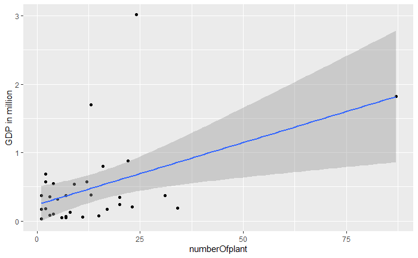

```r
finalset %>%
  ggplot(aes(x= numberOfplant, y = X2018Q4/1000000))+
  geom_point()+
  geom_smooth(method = "lm", formula= y~x)+ylab("GDP in million")
```

For the mid-southern states, Texas has the most number of wind power plant constrcution comparing with New Mexico, Oklahoma, and Kansas.

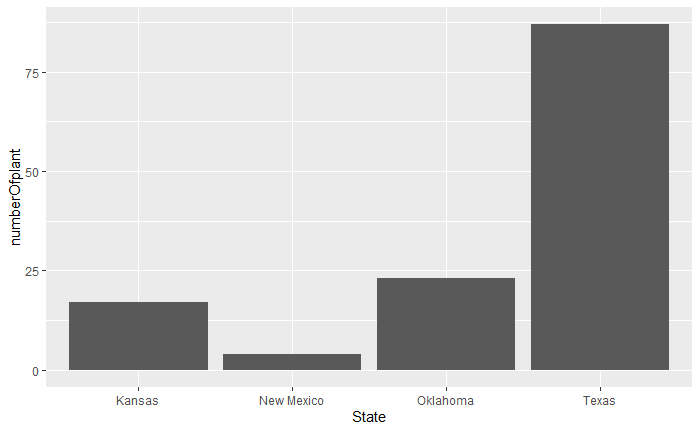

```r
finalsetS %>%
  ggplot(aes(x= State, y = numberOfplant))+
  geom_bar(stat= "identity")
```

The graph shows three different features: 1. Since most majority of the dot are clustered at the middle, it means that most of the power plant are built in the central area of the United States 2. Comparing to install capacity, the the northern has average 100 MWI as the line is flat, which means there is no linear relationship for northern part However, for the southern location, the for each degree of the power plant move to the east, the installed capacity will increase. (positive relationship) 3. Most of the size of the power plant are below 100 as the dot shows a deep blue color.

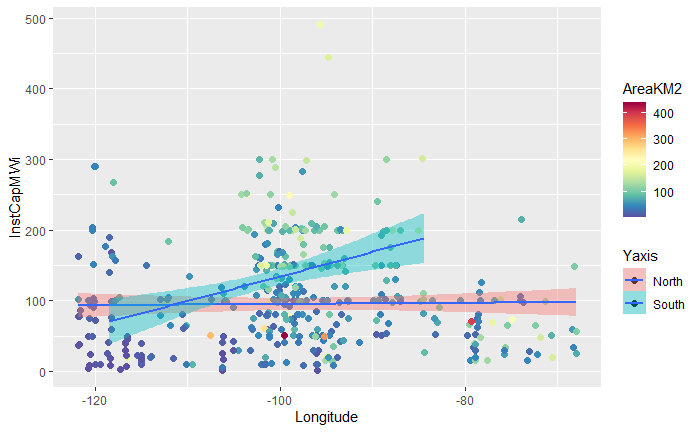

```r
myPalette <- colorRampPalette(rev(brewer.pal(11, "Spectral")))
sc <- scale_colour_gradientn(colours = myPalette(100))
windplant%>%
    ggplot(aes(x= Longitude, y= InstCapMWi, color = AreaKM2, fill = Yaxis))+
    geom_point(size = 2)+
    geom_smooth(method = "lm")+sc
```

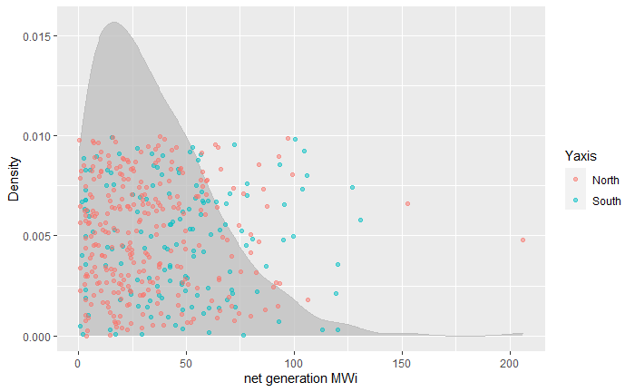

```r
windplant %>%
  ggplot(aes(x= NetGENe_2016_MWe, color = Yaxis))+
  geom_density(alpha = 0.75, color = "gray", fill = "gray")+
  geom_point(alpha = 0.5, aes(y = 0.005),
             position = position_jitter(height = 0.005)) +
  xlab("net generation MWi") +
  ylab( "Density")
```

The decision tree graph below is following the data frame of decisionT. It illustrates the possibility of having a wind power plant that have installed capactiy that is greater than 100 MWi:

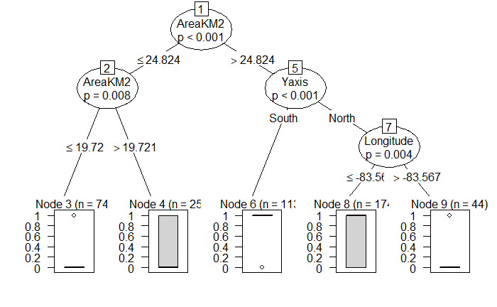

```r
library(party)
decisionT <- ctree(InstCapMWi >=100 ~AreaKM2+Longitude+Yaxis, data = windplant)
plot(decisionT)
```